# Patterns and causes of species richness: a general simulation model for macroecology - Gotelli - 2009 - Ecology Letters - Wiley Online Library

## Three gridded data layers

Three kinds of data layers are typically used to analyse spatial patterns of species richness: (1) a gridded map of a biogeographical domain, such as a continent or bioclimatic region; (2) species occurrence records within each grid cell of the domain; and (3) a set of contemporary (or increasingly, historical or future) environmental variables measured for each grid cell in the domain, such as average temperature, net primary productivity or topographic relief. These data layers are used in analyses of species richness patterns and form the inputs to the GSM.

Although beyond the scope of this paper, we note that many potential sources of error are associated with each data layer, and that the effect of these errors will probably vary with the spatial scale of the analysis. Recent studies have begun to explore the effects of measurement errors (e.g. Scott *et al.* 2002; Mathias *et al.* 2004; Guralnick & Van Cleve 2005; Hurlbert & Jetz 2007). However, in most analyses, process and measurement error are not distinguished, and they are pooled into a single error term. For now, we take the same approach and assume that, for high‐quality data sets analysed at an appropriate spatial scale, the underlying biogeographical signal of the data is not seriously distorted by inevitable uncertainty in the data layers. Explicit modelling of the processes that give rise to sampling errors is a promising avenue for future research.

## Curve‐fitting analyses of species richness patterns

How are the three kinds of data layers (gridded domain, species occurrences and environmental variables) typically analysed? Until recently, the most common approach has been to treat each grid cell as an independent sample, and then search for correlations between species richness and climate variables within the domain. For example, a simple linear regression of species richness of South American birds with net primary productivity (Rahbek *et al.* 2007) accounts for 44% of the variation in species richness among 1 × 1 degree grid cells (Fig. 1). This curve‐fitting approach, which typically uses linear functions and log‐transformed data, has characterized hundreds of published analyses that invoke measures of contemporary climate as arguably causal mechanisms of patterns in species richness. The strength of the mechanism is often inferred from the GOF (usually measured by *r*<sup>2</sup>), and by the frequency of studies that show such patterns. For example, Hawkins *et al.* (2003) concluded from a meta‐analysis that 83 of 85 studies strongly supported some aspect of the water‐energy hypothesis, because species richness was significantly correlated with grid‐cell measures of temperature or precipitation. In single‐factor regression analyses, climatic variables explained on average 60% of the variation in species richness in continental areas (Hawkins *et al.* 2003).

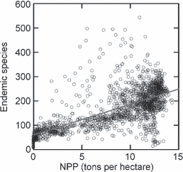

**Figure 1**

Linear regression of species richness of South American endemic birds vs. net primary productivity (NPP) (*r*<sup>2</sup> = 0.44, *P* < 0.001). Each point represents a single 1° × 1° latitude–longitude grid cell (*n* = 1676) (data from Rahbek *et al.* 2007).

## Limitations of curve fitting

The technical challenges of spatial autocorrelation (Rangel *et al.* 2006), inter‐correlated predictor variables (Mac Nally 2002), nonlinear responses of species richness to environmental variables (Mittelbach *et al.* 2001) and effects of spatial scale (Nogués‐Bravo *et al.* 2008) have defined much of the research programme in macroecology for the past decade. Curve‐fitting analyses have successfully identified repeated patterns of correlation between species richness and climatic variables. However, this extensive curve‐fitting activity has not led to satisfying explanations for the underlying causes of species richness gradients (Currie *et al.* 2004).

As noted by Currie *et al.* (1999), the core problem is that most hypotheses to account for large‐scale variation in species richness are specified so vaguely that they do not predict anything more precisely than a qualitative latitude–richness correlation (which served to motivate many of the hypotheses in the first place) or a simple correlation of species richness with measures of contemporary climate (which does not lead to unique predictions for different hypotheses). Notable exceptions include the species energy model (Wright 1983), the mid‐domain effect (Colwell & Lees 2000) and metabolic theory (Allen *et al.* 2002), all of which have recently been used to derive quantitative predictions of species richness patterns and to test those predictions with empirical data (Jetz & Rahbek 2001; Currie *et al.* 2004; Hawkins *et al.* 2007). A second problem is that both contemporary and historical factors influencing species richness are likely to interact in complex ways. We lack a body of theory to explain how these mechanisms will interact. Although causal modelling (Shipley 2009) is a potential approach to this problem, it has rarely been used in macroecology. The more common approach of using simple or multiple regression analysis is not an effective way of dealing with multicollinearity (Burnham & Anderson 2002). A final problem with curve‐fitting is that the response variable in the statistical model – species richness per grid cell – is the total number of species whose geographical ranges overlap each grid cell in the domain. A mechanistic understanding of species richness patterns should be based on modelling the actual species ranges themselves, rather than the aggregate variable of their summed overlap in each grid cell. The GSM directly addresses all three of these problems: it generates quantitative predictions of species richness per grid cell, incorporates multiple interacting processes and models species ranges directly.

## Bioclimatic distribution modelling strategies

Bioclimatic species distribution models (Pearson & Dawson 2003; Elith *et al.* 2006) use occurrence data to infer the environmental niche limits of a species, employing a variety of model‐fitting tools (Thuiller 2003; Latimer *et al.* 2006) and validation criteria (Araújo *et al.* 2005). Although bioclimatic species distribution models are essentially a form of sophisticated curve fitting, they are becoming more mechanistic (Thuiller *et al.* 2008). Recent models have incorporated processes such as dispersal and extinction (Iverson *et al.* 2004; De Marco *et al.* 2008), and have been coupled with stochastic population models (Keith *et al.* 2008). As species distribution models become more mechanistic, they converge in strategy with the modelling approach we advocate here.

Why not, then, simply apply bioclimatic species distribution models to each species in an assemblage, and then sum the predictions for each grid cell to derive expected species richness (McPherson & Jetz 2007; Fitzpatrick *et al.* 2008)? The primary reason we do not pursue this approach is that it requires estimating potentially hundreds of parameters as each species distribution is fitted, optimized and ‘trimmed’ using historical and ecological considerations. In contrast, we prefer a modelling strategy in which a set of similar, but not identical, species are modelled with a much smaller number of parameters (perhaps less than a dozen). An intermediate strategy for characterizing variation among species would be a ‘random effects’ model in which species differences are characterized by a probability distribution for each model parameter, or a model in which species are assigned to different functional groups, each with a different set of specified parameter values.

Of course, these deliberate simplifications can introduce other problems. For example, estimating dispersal with a single dispersal kernel for all species might give very different results from a model in which the dispersal kernel for each species was estimated separately. Colwell *et al.* (2009) have shown that, even in a homogeneous domain with a simple Poisson dispersal kernel, there is a strong interaction between dispersal distance *μ* and geographical range size in their effects on species richness per grid cell. At small and intermediate, but identical, range sizes, a simple spreading dye model produces complex species richness patterns that do not resemble a simple mid‐domain effect (Colwell *et al.* 2009). These effects of range size would be more accurately represented with separate parameters for each species in an assemblage than with a model that treats all species identically.

However, we can point to several examples of important models in ecology, including equilibrium theory (MacArthur & Wilson 1967), neutral theory (Hubbell 2001) and the metabolic theory of ecology (Brown *et al.* 2004), that assume species are ‘similar’ and are fitted with common parameters. These models have been surprisingly successful at explaining many patterns in large multi‐species assemblages. Indeed, the underlying premise of macroecology is that much of the variation in species assemblages is driven by only a small number of deterministic forces that can be described with simple stochastic equations (Brown 1995; Maurer 1999).

Finally, suppose the bioclimatic species distribution modelling perspective is correct, and the distribution of each species in nature must be represented by a unique model with parameters that are distinct from those of other species in the assemblage. If this were true, the resulting pattern of species richness might be expected to be complex and highly variable, but would not necessarily correlate very well with environmental or geographical variables because the predicted set of optimum conditions would be different for each species. In fact, the species richness of many taxonomic groups correlates very strongly with latitude, longitude, elevation, and a suite of associated environmental variables (Rosenzweig 1995). For the same reason that macroecologists have been successful in using curve‐fitting models to describe species richness as a function of water and energy variables (Hawkins *et al.* 2003), we believe there is merit in pursuing a modelling approach that does not focus on idiosyncratic differences among species.

## Mechanistic simulation models for species richness patterns

To overcome the limitations of the curve‐fitting approach, and to avoid the unwieldy strategy of predicting species richness by stacking species distribution models for individual species, we propose a third alternative: mechanistic models that simulate speciation, dispersal and extinction of species in a heterogeneous landscape (represented as a gridded domain). Simulation models are characteristically probabilistic and stochastic, so that multiple iterations of the same model can be used to empirically estimate the expected number of species (and its variance) in each grid cell of the domain, under the conditions of the model. A comprehensive, GSM must be flexible enough to incorporate and adjust major driving mechanisms of contemporary, past or future climates, evolutionary and historical forces, and geometric constraints. These mechanisms can be accommodated in a single GSM, potentially providing a common framework for investigating hypotheses about the relative influence on species richness of geometric constraints, climatic factors and historical processes.

However, the GSM poses some new challenges. It forces an explicit consideration of the precise rules that govern the origin of species and the expansion of their geographical ranges in a bounded domain, and it requires an estimate of the parameters that control these processes. Because the GSM approach predicts species richness patterns as they arise from the overlap of species ranges, the mechanisms by which range dynamics occur must be explicitly defined and coded as computer algorithms that operate with a specific time step and in a logical sequence.

The algorithms in the GSM represent a set of rules that govern the location, probability and mechanism of speciation, the inheritance of niche characteristics by each new species from its immediate ancestor, and the ability of each species to disperse to new grid cells and successfully colonize them based on their environmental characteristics. The model could be run for a given number of evolutionary time steps, until a particular number of species ranges are simulated, or until a balance between speciation and extinction is achieved, leading to a stationary distribution of species richness.

## Control knobs of the GSM

Each algorithm or procedure in the GSM can be thought of as controlled by a rotary knob, switch or dipswitch (Rosenzweig & Abramsky 1997). The setting of the control knob specifies the value of either a continuous parameter (e.g. like a water faucet) or a discrete multi‐state parameter (e.g. like an automobile headlight switch). Even a relatively simple model might have a dozen such control knobs. For purposes of discussion, it is useful to think of one of the settings on each knob as a ‘ground’ or ‘null’ state (the ‘off’ position on the water faucet or the headlight switch) that represents a parsimonious or unconstrained condition for the process. As an illustration, we consider just three of the control knobs in a GSM and their possible settings: dispersal distance, evolutionary origins and environmental gradients.

### Dispersal limitation

This control knob specifies limits on the distance, in grid‐cell units, that each species is able to disperse in a single time step of the model, thereby potentially colonizing a grid cell that it does not already occupy. The ‘ground state’ for this control knob would be dispersal within the domain that is unconstrained by distance, so that a species could potentially reach any grid cell in the domain in a single dispersal event. Many models in macroecology fit this scenario (Brown 1995); they describe assemblages for which species richness is ultimately determined by energetic constraints and other factors operating within a grid cell, unconstrained by the ability of species to reach those grid cells (Brown *et al.* 2004). At the other extreme, initial models of the mid‐domain effect (Colwell & Lees 2000) invoked strict range cohesion, so that species’ geographical ranges could spread only through contiguous, unoccupied grid cells. This constraint may reflect many biologically realistic processes that limit range expansion at smaller spatial scales, including environmental heterogeneity (Connolly 2005), strong dispersal limitation (Swenson & Howard 2005), source–sink dynamics (Curnutt *et al.* 1996) and metapopulation structure (Keitt *et al.* 2001). Between the extremes of unconstrained dispersal and strict range cohesion, the dispersal limitation control knob could be set to allow for dispersal across intervening grid cells (e.g. Rangel & Diniz‐Filho 2005b; Dunn *et al.* 2006; Colwell *et al.* 2009). Patch dynamics models reflect cases in which the intervening habitat is unsuitable for colonization (Connolly 2005).

The shorter this dispersal distance, the more closely the model will resemble the range cohesion model, and the longer the dispersal distance, the more closely the model will resemble unconstrained, spatially homogeneous dispersal. The longer the dispersal distance, the more holes or discontinuities will be generated in each species’ geographical range. Alternatively, patchy distributions could also arise in models with contiguous range expansion if local extinction is allowed to occur within occupied grid cells (Bokma *et al.* 2001; Davies *et al.* 2005; Rangel & Diniz‐Filho 2005b; Connolly 2009). We have had good success with a simple dispersal model in which dispersal distances follow a Poisson distribution with a common dispersal parameter μ for all species in the assemblage (Gotelli *et al.* 2007; Colwell *et al.* 2009). Modelling dispersal in this way allows for occasional long‐distance dispersal events, but requires the investigator to make decisions about which occupied grid cells are more likely to serve as dispersal sources. Does dispersal depend on the environmental conditions in the source and/or the target grid cell, or does it depend on the location of the source cell within the currently occupied range (edge vs. interior grid cells)? What is the fate of propagules targeted to disperse beyond the edge of the domain? Are these propagules ‘lost’ or can they ‘stop short’ to colonize unoccupied cells at the edge of the domain? If the grid cells in the domain are fairly large, a model of contiguous dispersal into adjacent cells may be more appropriate. In this case, the algorithm is similar to cellular automata, with rules specified for spreading into the adjacent four or eight cells (von Neumann or Moore neighbourhoods respectively). In preliminary trials (N.J. Gotelli, unpublished data), both methods give similar results, although the eight‐cell Moore neighbourhood is more efficient and leads to less porous species distributions.

### Evolutionary origins

This control knob sets the number of independent evolutionary origins for modelling the biota. The ground state of this control knob defines *n* independent evolutionary origins for a biota of *n* species. The origin of each species is a unique event, and evolutionary history (i.e. the position of the geographical range of the ancestor species) does not have an influence on the resulting pattern. Moreover, niche inheritance and niche conservatism (Losos 2008) are not explicit in this model: the niche of each species is independent of the niche of all other species. Most existing range‐based models of species richness (Jetz & Rahbek 2001; Grytnes 2003; Connolly 2005; Storch *et al.* 2006; Rahbek *et al.* 2007) treat the origin of each species as an independent event.

At the other extreme, a single evolutionary origin might initiate an entire clade that is distributed within a domain. In this class of models, each new species originates only within (or adjacent to) the geographical range of its ancestor. Evolutionary history potentially influences the pattern of species richness, and the model generates not only the expected species richness per grid cell but also a phylogeny, both of which could be compared to empirical data. Bokma *et al.* (2001), Rangel & Diniz‐Filho (2005a), Rangel *et al.* (2007) and Roy & Goldberg (2007) provide examples of such evolutionary models that include a single ancestral taxon that gives rise to a set of *n* extant taxa within a domain. As our understanding of the evolutionary relationships and biogeographical history of real organisms improves, it will become possible to set empirical values for the *n* independent origins parameter. For example, Pennington & Dick (2004) estimated that up to 20% of tree taxa in a sample of an Ecuadorean forest were members of clades descended from long‐distance immigrants from Africa.

The algorithmic details will need to address the geographical mode of speciation. If speciation is sympatric or from long‐distance dispersal (peripheral isolates), then the algorithm must specify the cell of origin and the dispersal kernel. If speciation is allopatric, then the algorithm must specify how existing geographical ranges are fragmented and whether the probability of fragmentation depends on measured environmental variables. Rangel *et al.* (2007) successfully used a stochastic sine‐wave function to simulate climate change and fragment ranges in an evolutionary model. These authors also used two simple, stochastic variables to control the ‘heritability’ of the environmental niche from ancestor to descendant taxon – one for the niche centre in niche space and the other for niche breadth. The niche centre parameter encompassed the extremes between perfect niche conservatism (the daughter taxon retains the environmental niche centre of the parent taxon) to rapid evolutionary adaptation (the niche centre of the daughter taxon evolves to match the mean environmental conditions of the parental range fragment from which the daughter originates). The niche breadth parameter controls the range of conditions tolerated around the niche centre.

### Environmental gradients

This control knob determines whether speciation, dispersal or extinction are equiprobable among grid cells or depend on particular environmental variables. Although most analyses and discussion of environmental variables focus on contemporary climate, new reconstructions of paleoclimates (Brewer *et al.* 2007; Salzmann *et al.* 2008) and paleo‐richness (FAUNMAP 2009) may provide data for realistic historical models that can be analysed with the GSM. Several control knobs may be necessary because the environmental factors that affect speciation might not be the same ones that determine dispersal or extinction. For terrestrial biotas, temperature and precipitation are two variables that are important correlates of large‐scale patterns of species richness, and therefore are likely candidate variables for the cell‐by‐cell weighting of dispersal and net speciation rates. The water‐energy model provides an emerging framework that may eventually yield functional forms for water and energy variables derived from first principles of physiology and physical constraints (O’Brien 2006). For now, however, these models are either conceptual only (Vetaas 2006; McCain 2007) or derived from regression parameters fitted to particular data sets (O’Brien 1998). Regardless of the details of the algorithms that determine the way in which climate affects the size and location of geographical ranges, the ground state of this control knob is a model in which all grid cells are equiprobable within a pre‐defined geographical domain and zero elsewhere.

## Model variations

Thus far, our simplified GSM has three control knobs (dispersal distance [DD], evolutionary origins [EO] and environmental gradients [EG]) that specify some key algorithms for simulating geographical ranges of species. If we consider each control knob in its dichotomous off‐on settings (where ‘off’ represents the ground state), we generate a set of eight qualitatively different kinds of simulation models (Table 1). Five of these models correspond well with recently published analyses and large‐scale simulations.

Table 1. Knob settings of a hypothetical GSM for simulating species richness patterns in a gridded domain

| Model | Dispersal limitation | Evolutionary origins | Environmental gradients | References |
| --- | --- | --- | --- | --- |
| Poisson random variable | 0 | 0 | 0 | Implicit null hypothesis in most curve‐fitting analyses (Levins 1969) |
| Spreading dye | 1 | 0 | 0 | Jetz & Rahbek (2001), Grytnes (2003), Connolly (2005) |
| Evolutionary origins | 0 | 1 | 0 |  |
| Range scatter | 0 | 0 | 1 | Implicit mechanistic model in most curve‐fitting analyses (e.g. Hawkins *et al.* 2003) |
| Range cohesion | 1 | 0 | 1 | Storch *et al.* (2006), Rahbek *et al.* (2007) |
| Neutral model | 1 | 1 | 0 | Bokma *et al.* (2001), Rangel & Diniz‐Filho (2005b), Davies *et al.* (2005), Connolly (2009) |
| Evolutionary origins + environmental gradients | 0 | 1 | 1 |  |
| Saturated model | 1 | 1 | 1 | Bokma *et al.* (2001), Rangel & Diniz‐Filho (2005a), Rangel *et al.* (2007), Roy & Goldberg (2007) |

- Knob settings of 0 represent a ‘ground state’ for each knob. Dispersal limitation: 0 = none, 1 = range cohesion or limited dispersal. Evolutionary origins: 0 = *n* independent evolutionary origins for a fauna of *n* species, 1 = (< *n*) independent evolutionary origins, generally 1. Environmental gradients: 0 = colonization and/or range expansion into all grid cells equiprobable, 1 = probabilistic colonization and/or range expansion into grid cells as a function of measured environmental variables.

The simplest model, with all three control knobs in the ground state [0‐0‐0; no dispersal limitation, *n*‐evolutionary origins, equiprobable environments], would yield a Poisson distribution of species richness per grid cell because each species occurrence is placed randomly, equiprobably and independently throughout the domain. This model corresponds to the statistical null hypothesis that is tested in many regression and curve‐fitting analyses. Levins (1969) original formulation of a single‐species metapopulation model also matches this category, as colonization occurs among patches in a homogeneous environment with no dispersal limitations. However, the Levins (1969) model is dynamic, as it includes continuous local extinction and recolonization, and it is not spatially explicit.

Imposing range cohesion and allowing each species to originate independently, in an equiprobable environment [1‐0‐0] describes the algorithm for the spreading dye model (Jetz & Rahbek 2001), in which each species originates in a randomly chosen grid cell, and then its range expands randomly and equiprobably into contiguous unoccupied grid cells until its specified range is filled. The spreading dye model is the simplest two‐dimensional simulation model of the mid‐domain effect (Colwell & Lees 2000). The analytical models of Grytnes (2003) and Connolly (2005) also fall in this category, although they do not constrain the frequency distribution of range sizes to match the empirical data. This category also includes models with partial dispersal limitation in a patchy environment (Connolly 2005).

Including only the constraint of evolutionary origins [0‐1‐0, a single geographical origin for all species] in an equiprobable, but bounded environment probably will not generate any geographical gradients in species richness, because all cells in the domain are equivalent and are equally accessible to colonists. However, because the origin of new species is no longer independent of the placement of previous species, this class of models could generate important deviations from a Poisson distribution of species richness and variance per grid cell.

A model with no dispersal limitation and multiple origins but with environmental gradients that affect origination, extinction or migration [0‐0‐1] is consistent with many hypotheses that invoke contemporary climatic or environmental effects (e.g. temperature, precipitation, productivity, harshness or environmental heterogeneity) as the primary determinants of species richness patterns. These scenarios, described as ‘range scatter’ models by Rahbek *et al.* (2007), assume that historical and evolutionary forces are relatively unimportant in determining patterns of contemporary species richness. Species are potentially able to reach all suitable grid cells within the domain, so that local species richness is controlled by some aspects of energy or other contemporary abiotic variables. Predictions of models in this category would be similar to simple regression‐based analyses of species richness, which implicitly assume that species richness within a grid cell does not depend on its location within the domain and is determined only by those environmental variables included in the regression model and a stochastic error term (e.g. Hawkins *et al.* 2003).

Imposing a dispersal constraint on a model with environmental gradients and multiple origins [1‐0‐1] produces a hybrid model that combines climatic and mid‐domain effects, leading to a spreading dye model in a heterogeneous environment (Storch *et al.* 2006; Rahbek *et al.* 2007). For the South American avifauna, these ‘range cohesion’ models did a better job of predicting species richness for wide‐ranging species than did either simple spreading dye models [1‐0‐0] or range scatter models [0‐0‐1] (Rahbek *et al.* 2007).

Models that specify a single evolutionary origin and dispersal limitation in an equiprobable environment [1‐1‐0] capture the spirit of the neutral model (Hubbell 2001), but differ from classic neutral models in specifying a bounded domain. At large biogeographical scales, with strong dispersal limitation, these models can generate mid‐domain peaks of species that are qualitatively similar to the predictions of the spreading dye and other two‐dimensional mid‐domain effect models (Rangel & Diniz‐Filho 2005b). Models that characterize speciation, colonization and extinction dynamics at the patch scale (rather than as individual births and deaths) also belong to this category (evolutionary origins models of Bokma *et al.* 2001; Davies *et al.* 2005; analytical patch occupancy models of Connolly 2009).

Models that include effects of environmental gradients and a single evolutionary origin but no dispersal constraint [0‐1‐1] have not been explored. Depending on the details of the speciation mechanism that is modelled, the lack of a dispersal constraint may or may not erase historical effects that arise during speciation.

The most complex combination in the GSM proposed here includes dispersal limitation, a single evolutionary origin and effects of environmental gradients [1‐1‐1]. Rangel & Diniz‐Filho (2005a) pioneered models in this class (in one and two dimensions), with a single, bounded, environmental gradient or geographical mosaic; a single evolutionary origin; and simple (peripatric) speciation and extinction rules. They showed that the resulting pattern of species richness is a balance between gradient strength and geometric constraints. Rangel *et al.*’s (2007) recent simulation of avian biogeography incorporates all of these effects on a complex map (South America), and incorporates many other ‘control knobs’ that specify rules for environmental fluctuation, range fragmentation and extinction, and the inheritance of the environmental niche characteristics from ancestor to descendant species.

Although each of the studies discussed here involves much more detail, specification of just three of the control knobs in the GSM effectively encompasses and classifies most published analytical and simulation models in macroecology.

## Estimating, optimizing and interpreting model parameters

Even a relatively simple simulation model can potentially contain many parameters. It is unlikely that all of these can be estimated independently with empirical data (Ricklefs 2003), so values of such parameters will have to be chosen on the basis of biological insight, expert opinion or parsimony. The parameters can then be adjusted or optimized to generate the best possible fit between the model output and empirical data. Parameter optimization for a GSM may be especially computationally intensive because a large number of model simulations will have to be run for each parameter combination to estimate the model’s predicted values of response variables. Moreover, applying standard algorithms for finding best‐fit parameter values (e.g. simplex, gradient or simulated annealing approaches; Kelly 1999) is also problematic because GOF surfaces for these stochastic models will not necessarily be smooth, so simplex and gradient algorithms may not converge on the optimal parameter sets. Genetic programming or reverse engineering algorithms (Bongard & Lipson 2007) may be needed to efficiently locate optimal (or near‐optimal) parameter combinations.

This strategy of adjusting and optimizing the parameters would produce a single synthetic model that incorporates several interacting mechanisms. Such a model would probably reflect the intuition of many macroecologists about the multiple factors that affect species richness (Harrison & Cornell 2007). However, such a model is likely to be unnecessarily complex. An alternative approach is to begin ‘turning off the control knobs’ of Table 1, and try to construct simpler models to account for variation in species richness. Rather than optimizing parameters to generate a single complex model, this approach uses the GSM to generate a suite of simple (null) models that can be viewed as alternative hypotheses. If there are *n* binary control knobs, there are 2<sup>*n*</sup> parameter combinations or qualitatively distinct models. This number may become prohibitively large for a realistic GSM, but it may not be necessary to test all model combinations to address the interactions of a few key mechanisms.

Finally, a comparative approach could be used for *a priori* comparisons of taxonomic groups that differ in dispersal ability or other features, or comparisons of a single taxonomic group among different biogeographical domains that differ in geological histories. In this way, the GSM can be used to explore complex narratives and hypotheses in historical biogeography (see Future challenges).

## Defining the response variable

Explaining the observed pattern of species richness per grid cell is the principal objective for building the GSM. In theory, different models can be assessed or ranked solely on the basis of their ability to account for variation in species richness. However, cases may arise in which two different models predict a similar pattern of species richness. For example, an evolutionary model that posits higher speciation rates closer to the tropics (Rohde 1992; Allen *et al.* 2002, 2006; Allen & Gillooly 2006), a niche conservatism model with tropical origins (e.g. Rangel *et al.* 2007) and an energetic model that posits more species where there is higher temperature or more energy available (Currie *et al.* 2004) would all predict a positive correlation between species richness and temperature.

How can we decide between competing models in such cases? Grimm *et al.* (2005) advocate the analysis of multiple response variables in assessing the output of complex simulation models. One of the great benefits of using the GSM is that it can generate many secondary predicted patterns for analysis. The output from any single run of the GSM can be organized as a binary presence–absence matrix, in which columns are the grid cells, rows are species and the matrix elements represent the presence (1) or absence (0) of a given species in a particular grid cell (Gotelli 2000). Traditional metrics derived from presence–absence matrices include the column sums (yielding the species richness per site, our primary response variable) and the row sums (resulting in the number of sites in which each species occurs). In this context, the row sums represent the predicted range‐size frequency distribution, which can be a possible secondary response variable (Rangel *et al.* 2007).

Moving beyond the simple row and column sums, presence–absence matrices enable the generation of additional response variables, including the ‘dispersion field’ (Graves & Rahbek 2005), which is the set of geographical range sizes of species occurring in a given cell, and the ‘diversity field’, which is the set of richness values of cells within the range of a given species (Arita *et al.* 2008). Patterns of dispersion and diversity fields may assist in model discrimination and evaluation. Other potential response variables that exploit the structure of the full matrix include the location of centres of endemism (Jetz *et al.* 2004), the degree of nestedness of the species assemblage (Ulrich *et al.* 2009), measures of beta diversity (Anderson *et al.* 2006; Jost 2007; Chao *et al.* 2008), and patterns in the scaling of species richness, including the species–area relationship (Arita & Rodriguez 2002; Lyons & Willig 2002).

An entirely different dimension can be added to all these metrics if rows (species) are classified according to a phylogeny generated by the model itself, and the geographical position of columns (grid cells) is explicitly included in the model. This enables the analysis of response variables in spatial and temporal evolutionary contexts that might allow a finer tuning of contrasting models. First, the shapes of the generated phylogenies themselves can be compared with observed phylogenies using metrics such as tree balance (e.g. Heard & Cox 2007) and the pattern of lineage‐branching pattern through time (e.g. White *et al.* 2006; Alroy 2008; Phillimore & Price 2008). Second, the phylogenetic community structure (*sensu*Webb 2000) of taxa co‐occurring in samples of spatially contiguous cells can be compared between observed and simulated cases. We expect high phylogenetic clustering at these biogeographical scales either when dispersal limitation is high and a spatial signature of speciation persists for a long time (Graham & Fine 2008) or when strong environmental gradients are combined with strong phylogenetic niche conservatism (Wiens & Graham 2005; Losos 2008). Third, specific phylogeographical patterns can be examined: e.g. how often in simulated cases do taxa within some spatially or environmentally defined region form a clade of the same size and shape as is seen in the observed phylogeographical distribution? A latitudinal gradient of species richness could thus be examined, shedding light on the many competing evolutionary hypotheses that have been proposed to explain the pattern (Wiens & Donoghue 2004; Jablonski *et al.* 2006; Mittelbach *et al.* 2007; Arita & Vázquez‐Dominguez 2008; Jablonski 2008). Finally, if additional traits or attributes of species have been measured, there are numerous indices for describing the distribution of trait states among terminal taxa (e.g. Blomberg *et al.* 2003).

In combination with species richness per cell, all these secondary patterns facilitate discrimination among models. However, there are difficulties with this approach because not all of the response variables are produced by all of the models, and some models make use of the empirical distribution of some of the response variables. For example, the evolutionary model of *n* independent origins does not generate a phylogeny; conversely, many simple spreading dye models use the observed range‐size frequency distribution to generate model predictions, so these variables could not be used to evaluate models. Indeed, it is arguable that formal model selection statistics should not be used for any response variables when comparing, e.g. a model that uses the observed range size frequency distribution and one that predicts the range size frequency distribution. An additional challenge is that models that optimize the fit to one of the response variables (such as the number of species in each grid cell) may do so at the expense of others (such as the range size frequency distribution). Although the GSM predicts species richness and a number of other macroecological patterns, it is unclear how much weighting should be given to secondary patterns for the purposes of assessing GOF.

## Assessing model adequacy and comparing models

For a GSM to be useful, we must be able to identify models that fit the observed data well, to measure the adequacy of the fit for each model and to rank competing models against one another in terms of their predictive power. We focus here on modelling the number of species in each grid cell, leaving aside other model predictions such as phylogenetic patterns or range size frequency distributions.

To compare the models directly with one another for their predictive capability, we can use the sum of the MSEs, as follows:

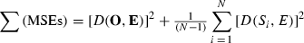

In addition to ranking a set of models according to their precision and low bias, it will often be informative to assess the adequacy of a single model against the data. For testing the GOF of a particular model based on count data such as species richness, we suggest using the Kullback–Leibler (or K–L) distance (Kullback & Leibler 1951). The K–L distance [*K*(*O*,*E*)] compares the observed (empirical) data *O* with species richness predicted by the model, *E*:

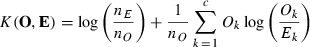

The next step is to assess the distribution of the K–L distances under the null hypothesis that the model is correct (i.e. its output accurately matches the empirical data). An intuitive way to estimate this distribution is to simulate a large number of data sets (*S*<sub>1</sub>, *S*<sub>2</sub>, …, *S*<sub>*i*</sub>,…, *S*<sub>*N*</sub>) that *do* conform exactly to the model’s assumptions, and then calculate the K–L distances associated with the simulated data sets (Tsay 1992; Waller *et al.* 2003). These K–L distances *K*(*S*<sub>i</sub>, *E*), *i* = 1, 2, …, *N* form a parametric bootstrap distribution (Efron & Tibshirani 1993; White 2002) that can be used directly for hypothesis testing. The *P*‐value is estimated directly as the proportion of simulated *K*(*S*<sub>*i*</sub>, *E*) distances that is greater than or equal to *K*(*O*, *E*). This empirical testing procedure assumes that simulations are independent of one another, but (importantly) does not assume independence among the cells within a given simulation, nor does it make any assumption about the nature of the distribution of the K–L distances.

Analyses such as comparisons of MSE values and tests based on K–L distances will allow investigators to quantify the accuracy and precision of different simulation models, to rank competing models and to perform GOF tests for individual models. These tests can be performed on contemporary species distributions and environmental variables, but they can also be adapted for evaluating changes in species richness through time. In addition, diagnostic tools and residual plots can be used to identify individual grid cells or geographical regions in which a model’s predictions consistently overestimate or underestimate species richness.

## Future challenges

We have argued that stochastic simulation models of species occurrences provide a powerful complement to traditional curve‐fitting and more recent bioclimatic species distribution modelling. However, the GSM is not a panacea. As with traditional curve fitting and bioclimatic species distribution modelling, the results will be sensitive to the spatial scale and taxonomic resolution of the data. Moreover, our ability to test historical hypotheses will be limited by the availability of good phylogenies and (especially) environmental data layers for historical climates. Nevertheless, simulation models hold great promise for understanding the role of historical and contemporary forces in shaping species richness patterns and for projecting species richness under climate change.

In closing, we note that the subdiscipline of historical biogeography (Morrone & Crisci 1995) also has tried to link patterns of species diversity to historical and evolutionary processes through the mapping of contemporary diversity on phylogenies, areograms and vicariant events (Platnick & Nelson 1978; Rosen 1978; Nelson & Platnick 1980). Perhaps the development of a detailed GSM will provide a conceptual bridge between macroecology and historical biogeography (Brooks 1990; Cracraft 1994).

## Acknowledgements

This study is a contribution of the Synthetic Macroecological Models of Species Diversity Working Group supported by the National Center for Ecological Analysis and Synthesis, a Center funded by NSF (Grant #DEB‐0553768), the University of California, Santa Barbara and the State of California. Additional funding for group meetings was provided by the Australian Research Council Environmental Futures Network. Gotelli was supported by NSF DEB‐0541936, and Colwell and Rangel were supported by NSF DEB‐0072702. We thank D. Nogues‐Bravo, W. Thuiller and two anonymous referees for comments that improved the manuscript.

### Details

  © 2009 Blackwell Publishing Ltd/CNRS